# Final Project Report by Katie Aman

2023-12-01

## Katie’s RMarkdown Report (HTML)

# Figures Section

## Figure 1

Here is my first plot! I decided to create a histogram of the ages in my data set. There is a column for occupation in my data set and it does look like this data set is representative of working professionals. Our ages range from 27-59, which is not representative of a normal population. This confirmed my initial suspicions about this data set not being really representative of a specific population I can think of in public health. We have a lot of people in their 30s and mid 40s here with some more in their early and late 50s. There are very few people under 30 years old in the data set.

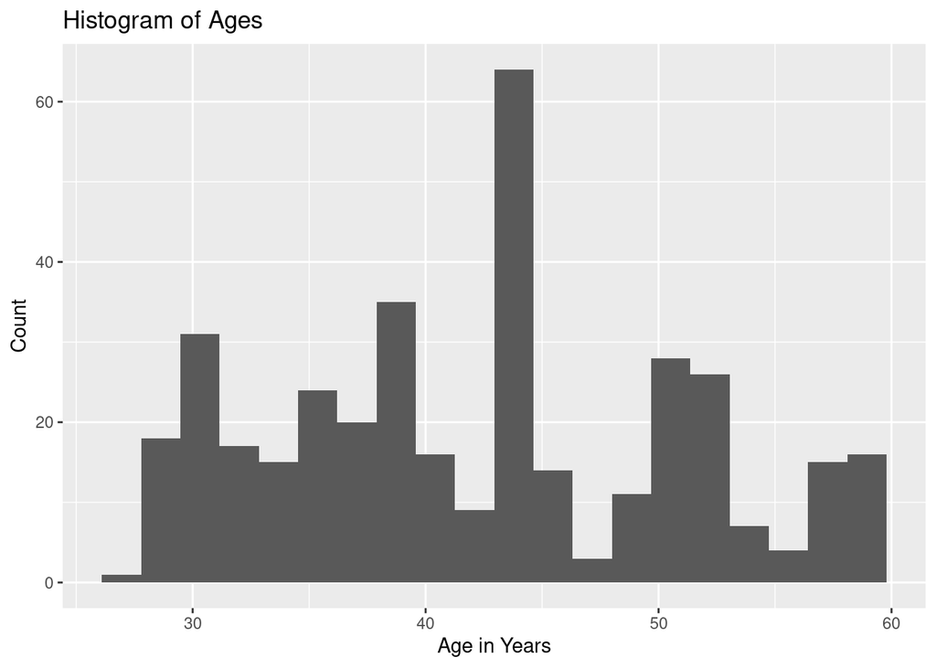

## Figure 2

Now, I’m going to walk through my second figure. I did something very basic and made a boxplot of sleep duration. I want to see how it looked. It appears that the median amount of sleep in the data set is close to 7.2 hours of sleep a night. This actually seems reasonable considering a lot of people sleep between 6-8 hours every night. It seems that 50% of the data is within 6.4 to 7.8 (roughly) hours of sleep per night. As an athlete, I do know a fair bit about sleep and this isn’t great. I guess getting above 7 hours of sleep a night is decent, but it would be good if we saw the median closer to 7.5-8 hours a week. But this is certainly not terrible for a lot of people who appear to be lawyers, doctors, and engineers and are likely pretty busy.

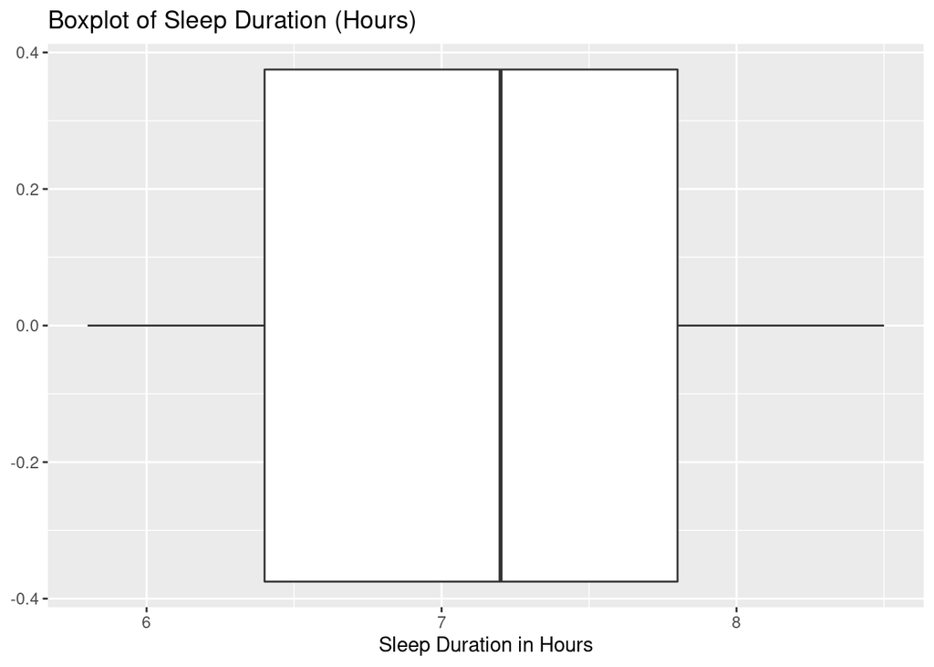

## Figure 3a and 3b

I decided I wanted to graph both diastolic blood pressure and systolic blood pressure against physical activity level (minutes/day). My guess was that we might see a trend with fewer minutes of physical activity and both a higher diastolic and/or systolic blood pressure. I also knew that this data set had duplicate values so I decided to make the scatter plot have frequency integrated into it by the size of the dots. I couldn’t really discern anything from these graphs. With the high values for both blood pressure measurements, people seemed to be doing the most minutes of exercise. Perhaps this is because their doctors told them they needed to exercise to bring their blood pressure back in line. We also just don’t have a lot of information on the blood pressure measurements or the level of exercise. Although the graphs not showing any patterns frustrated me a bit, I do realize this is a part of data analysis. There are plenty of times the data is going to show absolutely nothing.

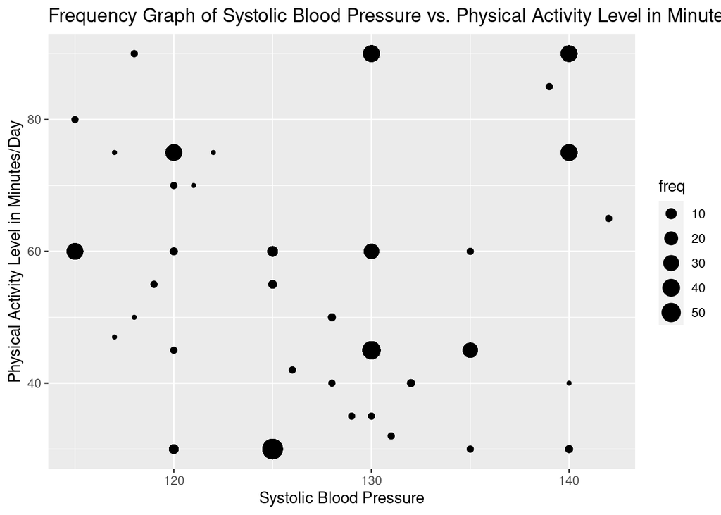

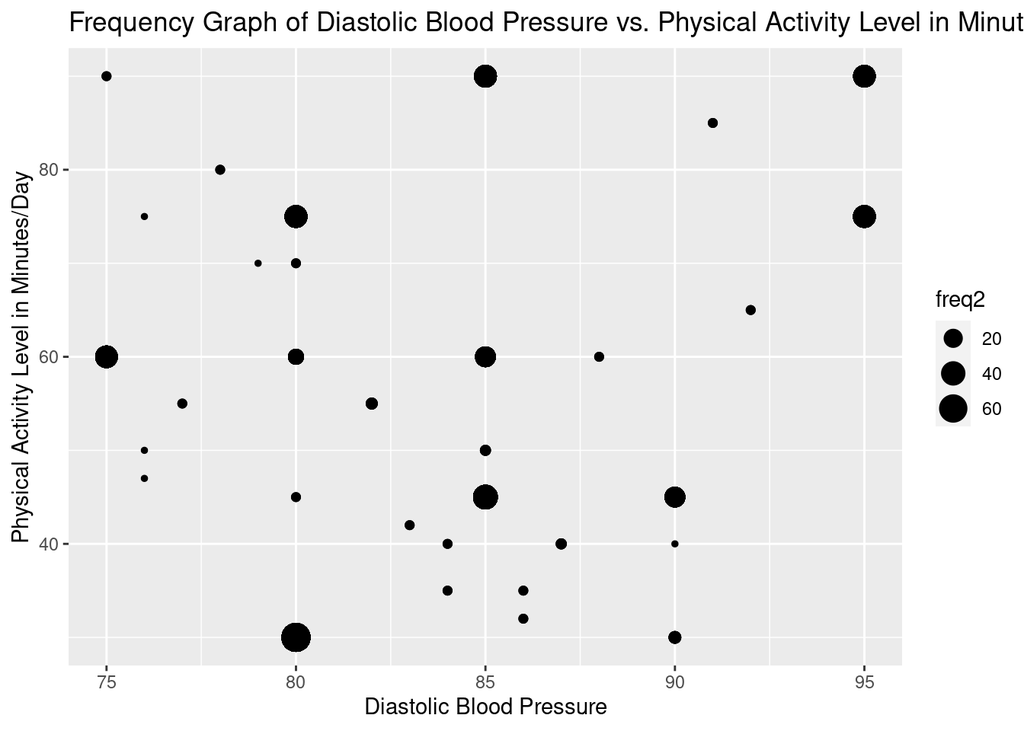

## Figure 4

This figure uses the tile graph to show the relationship between stress level and quality of sleep, which are both discrete variables. I colored the tiles by frequency. There is a very strong relationship that appears between getting worse quality of sleep (smaller numbers) and the stress level being high. When stress levels are low, it seems the quality of sleep is much higher. There is a high frequency of stress level 8 and quality of sleep 6, stress level 5 and quality of sleep 8, and lastly stress level 3 and quality of sleep 9.

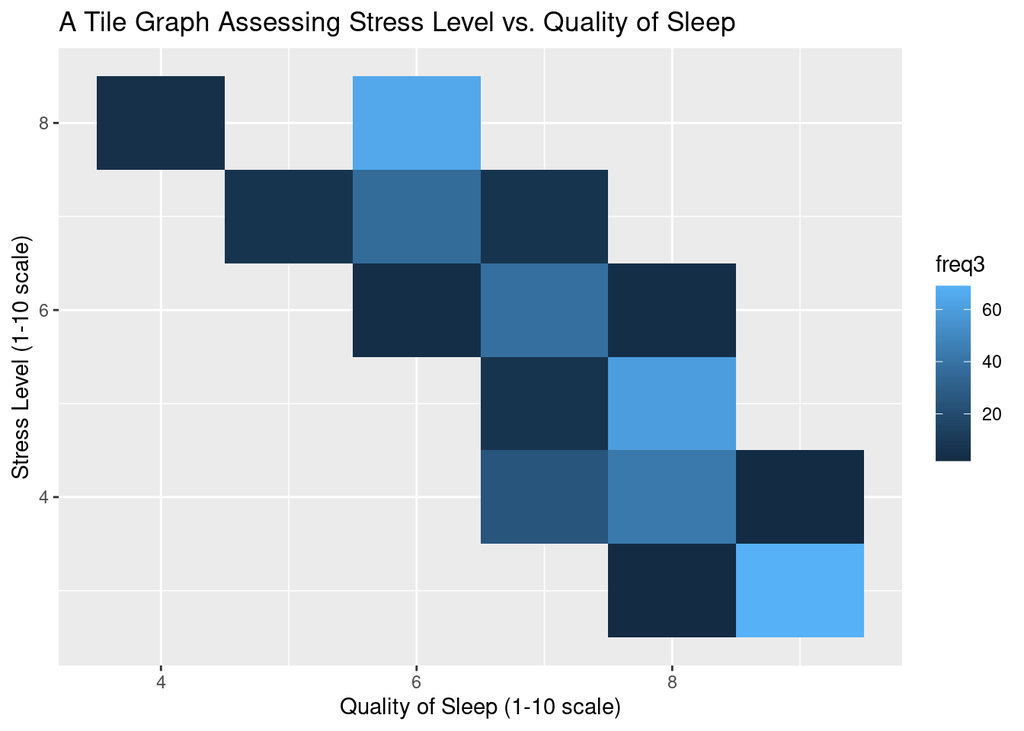

## Figure 5

My last official figure shows sleep duration by occupation with the counts of average amount of sleep on every bar. I took the average amount of sleep by profession to create this bar chart. Sales representatives have the smallest average sleep per night at 5.9 hours and engineers get the most at 7.99 hours. Some professions also have very few unique entries so we need to be careful here.

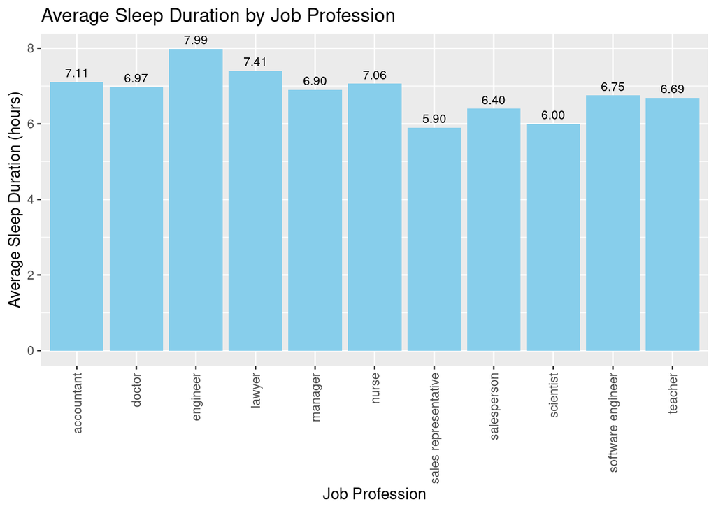

# Analysis Through PCA

I used PCA to look at my data and analyze it. First, I hot encoded my categorical variables. Then, I did some graphing and you can see the strange colorful blue chart for evidence and the PCA scatter plot. I realized that hot encoding the variables was actually probably not the best, but I saw no clusters in the first graph. So, I then ran the PCA again. I got another very colorful chart that is not super discernible but it looks like there might be some pattern. I then created multiple scatter plots with the PCA analysis. All of 4 of the graphs do have some level of a pattern. I thought the graphs colored by gender and BMI category potentially followed some of the clusters better than the other graphs, but I’m very new to principle component analysis and there could also not be any patterns here at all. But it would be hard to convince you that the data is outright boring!

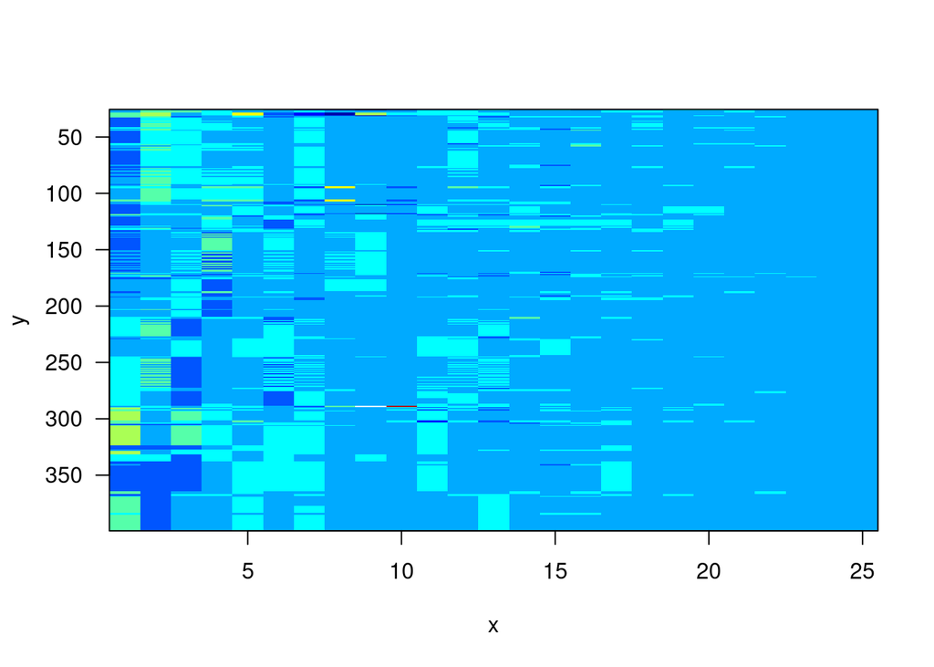

```
## Importance of components:
##                           PC1    PC2    PC3     PC4     PC5    PC6     PC7
## Standard deviation     2.3933 2.0941 1.6946 1.30298 1.23542 1.1180 1.08806
## Proportion of Variance 0.2291 0.1754 0.1149 0.06791 0.06105 0.0500 0.04735
## Cumulative Proportion  0.2291 0.4045 0.5194 0.58730 0.64835 0.6983 0.74570
##                            PC8    PC9   PC10   PC11    PC12   PC13    PC14
## Standard deviation     1.01709 1.0100 1.0049 0.8631 0.80641 0.7159 0.62563
## Proportion of Variance 0.04138 0.0408 0.0404 0.0298 0.02601 0.0205 0.01566
## Cumulative Proportion  0.78708 0.8279 0.8683 0.8981 0.92408 0.9446 0.96024
##                           PC15    PC16   PC17    PC18    PC19    PC20    PC21
## Standard deviation     0.56198 0.48127 0.4302 0.27909 0.24321 0.23241 0.21867
## Proportion of Variance 0.01263 0.00926 0.0074 0.00312 0.00237 0.00216 0.00191
## Cumulative Proportion  0.97287 0.98214 0.9895 0.99266 0.99502 0.99718 0.99910
##                          PC22    PC23      PC24      PC25
## Standard deviation     0.1324 0.07102 4.159e-16 3.231e-16
## Proportion of Variance 0.0007 0.00020 0.000e+00 0.000e+00
## Cumulative Proportion  0.9998 1.00000 1.000e+00 1.000e+00
```

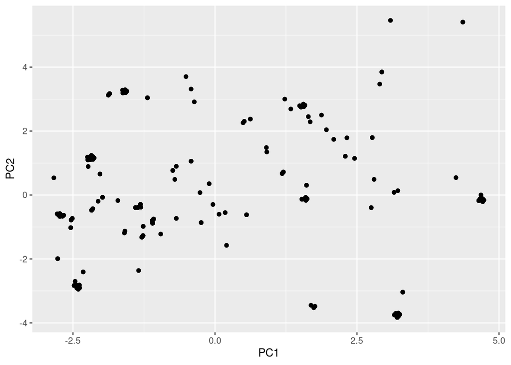

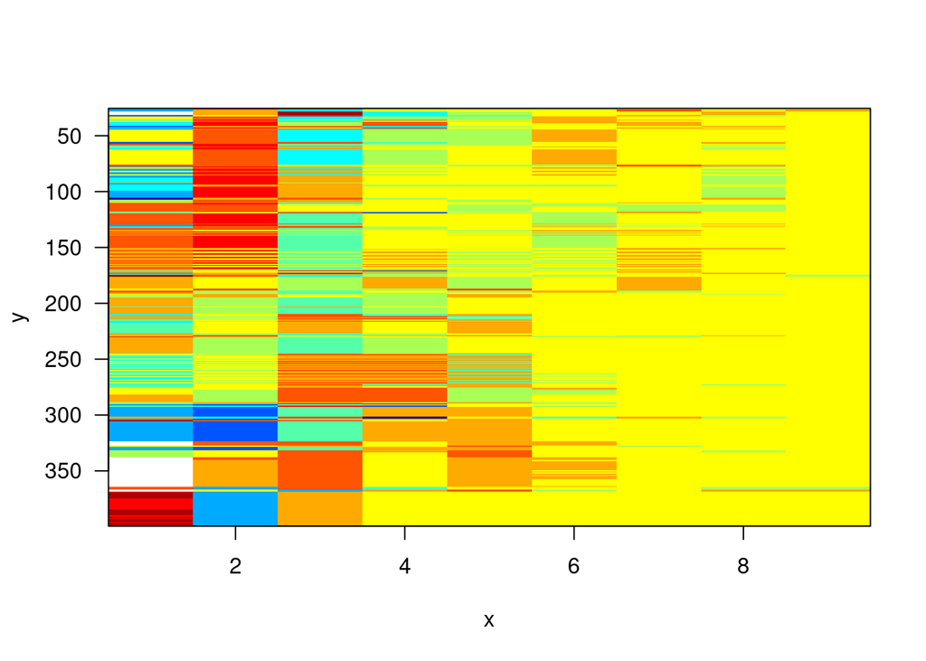

```
## Importance of components:
##                           PC1    PC2    PC3     PC4    PC5     PC6     PC7
## Standard deviation     1.8720 1.6697 1.2452 0.77695 0.5170 0.36749 0.28336
## Proportion of Variance 0.3894 0.3098 0.1723 0.06707 0.0297 0.01501 0.00892
## Cumulative Proportion  0.3894 0.6991 0.8714 0.93847 0.9682 0.98318 0.99210
##                            PC8     PC9
## Standard deviation     0.24080 0.11438
## Proportion of Variance 0.00644 0.00145
## Cumulative Proportion  0.99855 1.00000
```

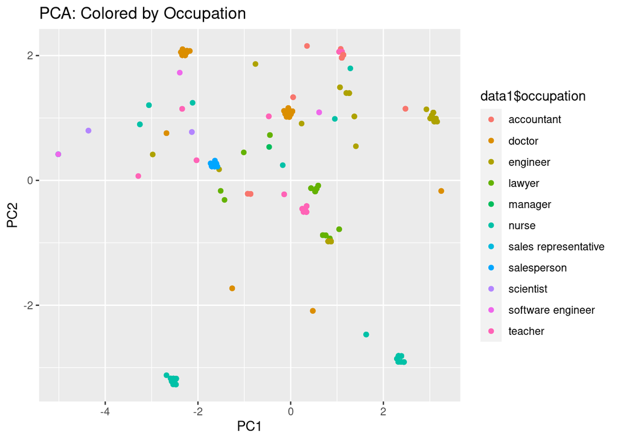

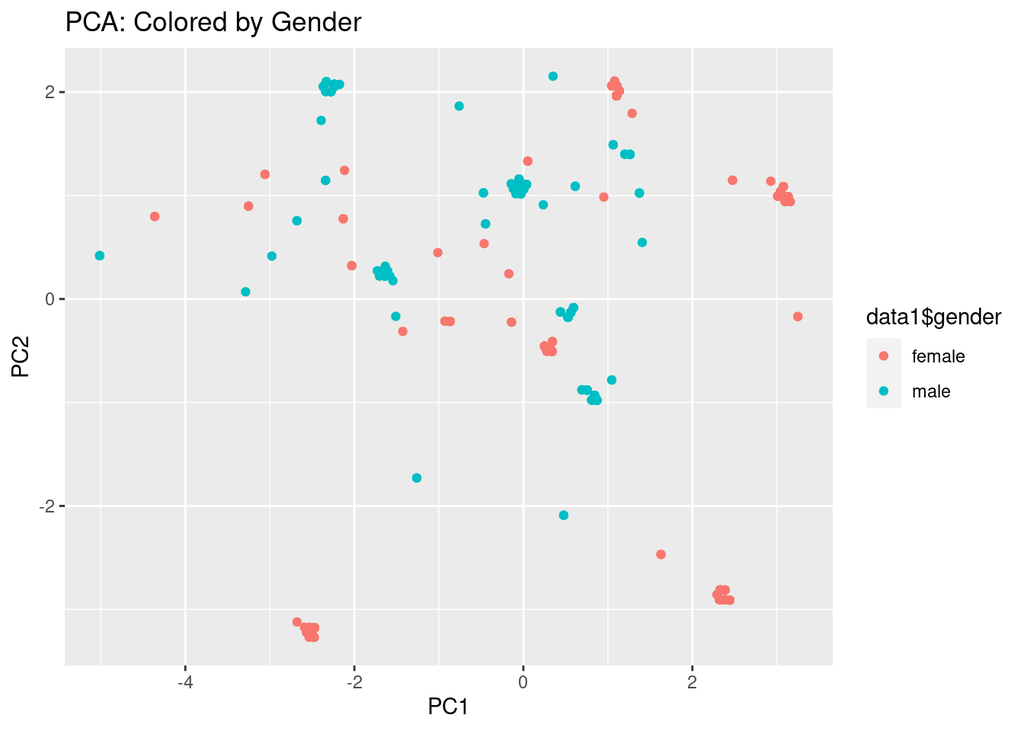

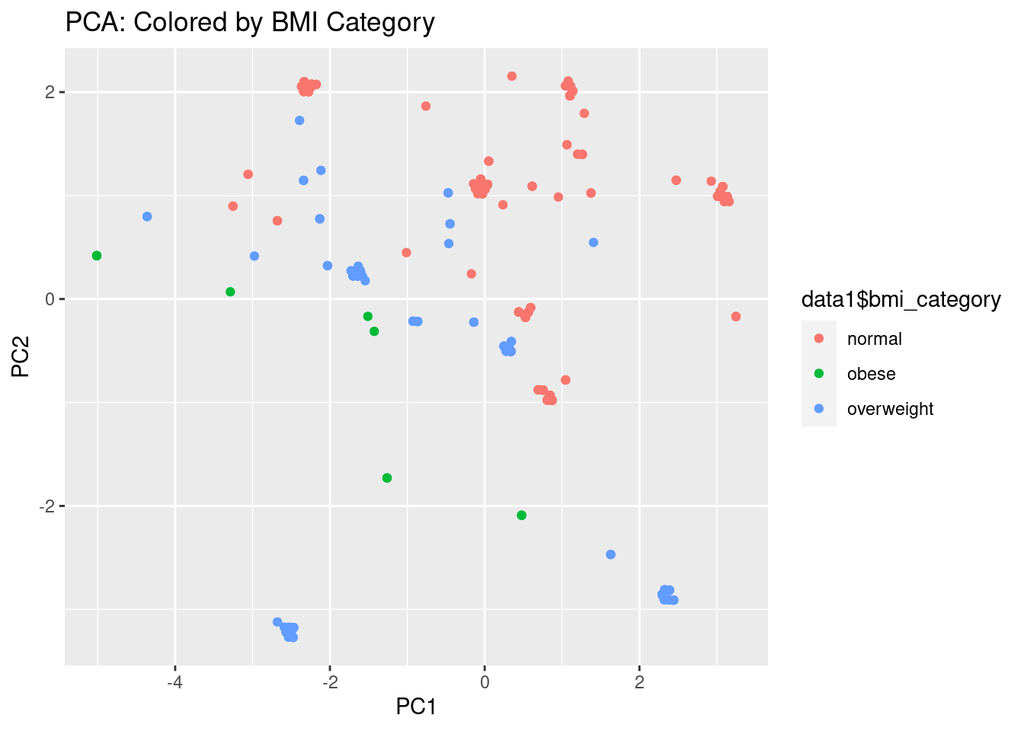

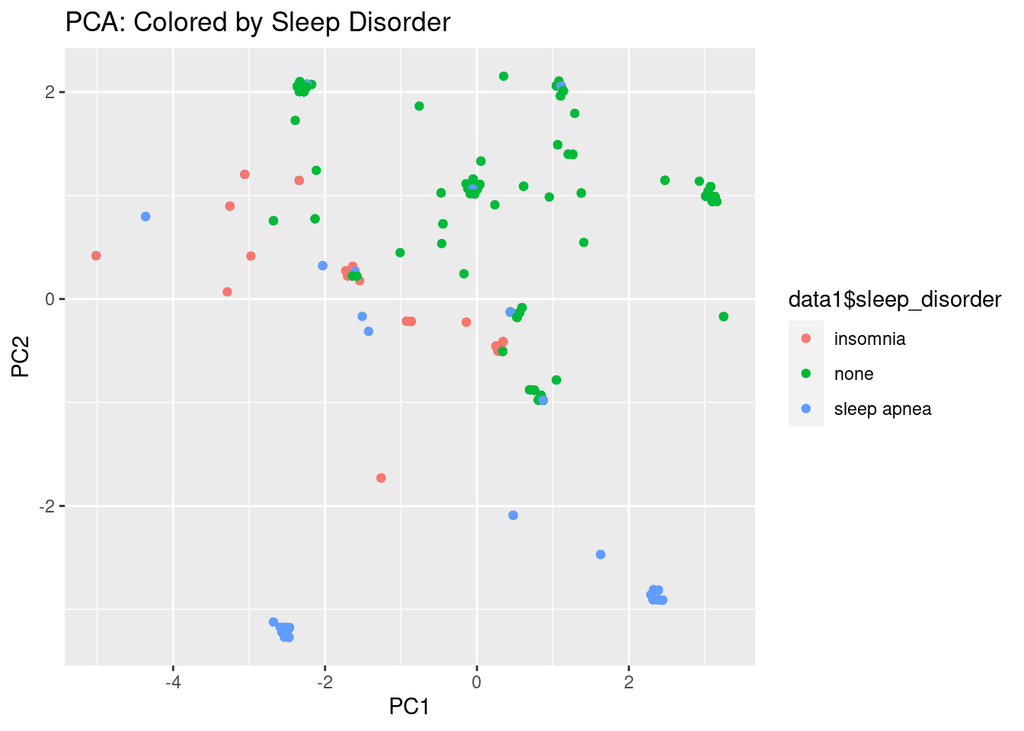

# Basic Random Forest Model to Predict Occupations

Lastly, I wanted to make a very basic predictive model to see if it could predict the occupation of people in the data set based on all the other variables. It seemed to do okay actually with the Random Forest model employed, but we don’t have a lot of data so perhaps I should be cautiously optimistic. But it’s cool to see that the PCA may have held something interesting if the predictive model also performed okay by using other variables in the data set.

```
##
## Call:
##  randomForest(formula = formula(paste(target_variable, "~", paste(features,      collapse = "+"))), data = data1)
##                Type of random forest: classification
##                      Number of trees: 500
## No. of variables tried at each split: 3
##
##         OOB estimate of  error rate: 5.88%
## Confusion matrix:
##                      accountant doctor engineer lawyer manager nurse
## accountant                   34      0        1      0       0     0
## doctor                        0     71        0      0       0     0
## engineer                      2      0       59      0       0     0
## lawyer                        0      0        0     46       0     1
## manager                       0      0        0      1       0     0
## nurse                         2      0        1      0       0    69
## sales representative          0      0        0      0       0     0
## salesperson                   0      0        0      0       0     0
## scientist                     0      0        0      0       0     0
## software engineer             0      1        0      0       0     0
## teacher                       6      0        0      0       0     0
##                      sales representative salesperson scientist
## accountant                              0           0         0
## doctor                                  0           0         0
## engineer                                0           0         0
## lawyer                                  0           0         0
## manager                                 0           0         0
## nurse                                   0           0         0
## sales representative                    2           0         0
## salesperson                             0          32         0
## scientist                               0           0         4
## software engineer                       1           0         0
## teacher                                 0           0         0
##                      software engineer teacher class.error
## accountant                           0       2  0.08108108
## doctor                               0       0  0.00000000
## engineer                             0       2  0.06349206
## lawyer                               0       0  0.02127660
## manager                              0       0  1.00000000
## nurse                                0       1  0.05479452
## sales representative                 0       0  0.00000000
## salesperson                          0       0  0.00000000
## scientist                            0       0  0.00000000
## software engineer                    2       0  0.50000000
## teacher                              1      33  0.17500000
```

# Conclusion

This was an instructive exercise on going through data and using the tools I used all semester long. My future questions would be to see if my predictive model and principle component analysis would generate similar results on a bigger data set. I would love to see how my results here stack up against a larger data set and also from a more defined population. I feel like my results here are limited by the fact that I don’t know where this survey was done and not sure how everything was measured. I would need better objective measurements and to know how each variable was taken/recorded, along with a more defined population (a sample of working people, a subset of the U.S. population, etc). I think it would be very cool to also add measurements about hypertension, heart disease, and other variables related to health. I also simply did not have the time in this to do all the analysis I wanted or envisioned, but it gives me good ideas for the future.